# STSCI_5999

# Feb.27, 2020

```python
import pandas as pd
import numpy as np

import matplotlib.pyplot as plt
from matplotlib import cm
from matplotlib.ticker import LinearLocator, FormatStrFormatter
from mpl_toolkits.mplot3d import Axes3D
import IPython.display as IPdisplay
import imageio
```

```python
data1 = pd.read_csv("dataset2016-2018.csv")
data1.head(10)
```

|  | order_id | bin | payment_type | billing_city | billing_postal_code | retry_indicator | traffic_provider | M0_Approval% |
| --- | --- | --- | --- | --- | --- | --- | --- | --- |
| 0 | 9426995 | 408537 | Visa | HAMPTON | 3842 | 0 | N\A | 1.000000 |
| 1 | 11614239 | 412739 | Visa | KATY | 77494 | 0 | MobileSite-PD-TextLink-SeeExactAddress | 1.000000 |
| 2 | 11614242 | 379743 | American Express | MADISON | 39110 | 0 | 22 | 1.000000 |
| 3 | 11614257 | 400344 | Visa | LIVE OAK | 32060 | 0 | PropContact | 1.000000 |
| 4 | 11614281 | 517760 | MasterCard | POMPANO BEACH | 33065 | 0 | N\A | 0.000000 |
| 5 | 11614283 | 473703 | Visa | NORFOLK | 23503 | 0 | trulia foreclosures | 1.000000 |
| 6 | 11614289 | 437307 | Visa | KANSAS CITY | 66106 | 0 | MobileSite-PD-TextLink-SeeExactAddress | 0.333333 |
| 7 | 11614312 | 416993 | Visa | ROYSTON | 30662 | 0 | N\A | 0.000000 |
| 8 | 11614316 | 441244 | Visa | HEADLAND | 36345 | 0 | HeaderMenuJoin | 1.000000 |
| 9 | 11614349 | 430326 | Visa | WHARNCLIFFE | 25651 | 0 | Mobile_Banner | 0.000000 |

```python
# bin_count = data1.groupby('bin')['bin'].nunique()
# bin_count
bin_count = data1['bin'].value_counts()
bin_count = pd.DataFrame({'bin':bin_count.index, 'count':bin_count.values})
bin_count.head(10).style.hide_index()
```

| bin | count |
| --- | --- |
| 517805 | 6013 |
| 533248 | 3254 |
| 473702 | 3193 |
| 601100 | 2096 |
| 434256 | 1992 |
| 426684 | 1800 |
| 444796 | 1759 |
| 473703 | 1667 |
| 403995 | 1643 |
| 400022 | 1560 |

## Data visualization

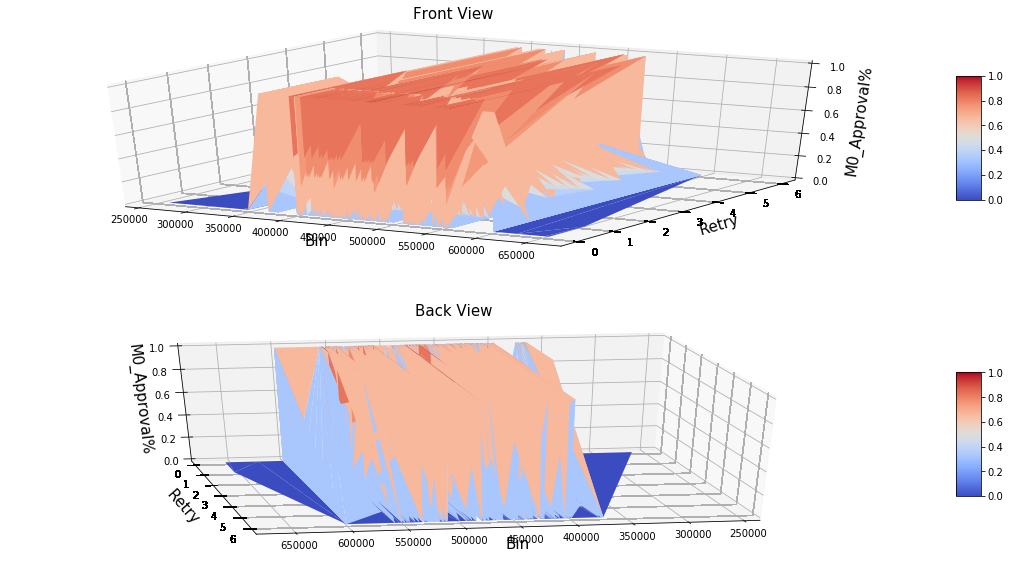

```python
fig = plt.figure(figsize=[20,10])

ax = fig.add_subplot(2,1,1, projection='3d')

yticks = data1['retry_indicator']

surf = ax.plot_trisurf(data1['bin'], data1['retry_indicator'],data1['M0_Approval%'] ,
                       cmap=cm.coolwarm, linewidth=0)
fig.colorbar(surf, shrink=0.5, aspect=5)

labelsize=15
ax.set_xlabel('Bin', fontsize=labelsize)
ax.set_ylabel('Retry', fontsize=labelsize)
ax.set_zlabel('M0_Approval%', fontsize=labelsize)
ax.set_title('Front View', fontsize=15, x=0.5, y=1.04)

ax.set_yticks( yticks )
ax.tick_params(axis='both', labelsize=10 )


ax = fig.add_subplot(2,1,2, projection='3d')

yticks = data1['retry_indicator']

surf = ax.plot_trisurf(data1['bin'], data1['retry_indicator'],data1['M0_Approval%'] ,
                       cmap=cm.coolwarm, linewidth=0)
fig.colorbar(surf, shrink=0.5, aspect=5)

labelsize=15
ax.set_xlabel('Bin', fontsize=labelsize)
ax.set_ylabel('Retry', fontsize=labelsize)
ax.set_zlabel('M0_Approval%', fontsize=labelsize)
ax.set_title('Back View', fontsize=15, x=0.5, y=1.04)

ax.set_yticks( yticks )
ax.tick_params(axis='both', labelsize=10 )


ax.view_init(30, 80)
plt.show()
```

```python
fig = plt.figure(figsize=[15,10])

yticks = data1['retry_indicator']

ax =fig.add_subplot(111, projection='3d')

surf = ax.plot_trisurf(data1['bin'], data1['retry_indicator'],data1['M0_Approval%'] ,
                       cmap=cm.coolwarm, linewidth=0)
fig.colorbar(surf, shrink=0.5, aspect=5)

labelsize=15
ax.set_xlabel('Bin', fontsize=labelsize)
ax.set_ylabel('Retry', fontsize=labelsize)
ax.set_zlabel('M0_Approval%', fontsize=labelsize)
ax.set_title('Bin - Retry - Approval', fontsize=15, x=0.5, y=1.04)

ax.set_yticks( yticks )
ax.tick_params(axis='both', labelsize=10 )

gif_filename='Bin_Retry_Approval'

filenames=[]

#Rotating
for n in range(-120, 120, 2):
    ax.view_init(30, n)
    plt.savefig('images/' + gif_filename + '/img' + str(n).zfill(3) + '.png',
                bbox_inches='tight')
    filenames.append('images/' + gif_filename + '/img' + str(n).zfill(3) + '.png')

plt.close()


file_path_name =  gif_filename + '.gif'

#Making .gif
images = []
for filename in filenames:
    images.append(imageio.imread(filename))
imageio.mimsave(file_path_name , images)

#Display .gif
IPdisplay.Image(url=file_path_name)
```

[figure not shown]

### Conclusion from the graph:

- Better "bins" are shown in the "red" part.
- Bins within 350000 to 550000 are more likely to have higher approval rates, this result agree with our plot from R.
- Bins with high "retry" attempts will more likely to have lower approval rates.

From this plot we know the overall distribution of the data. Next, we can try some clustering methods that can hopefully generate a more accurate way to seperate the "red" part.

## Decision tree

```python
import graphviz
from sklearn import tree
from sklearn.tree import DecisionTreeClassifier
from sklearn.model_selection import train_test_split
from sklearn import metrics
from graphviz import Source

from sklearn.metrics import roc_curve, auc
```

```python
# X is the feature variables that contains 'bin' and 'retry_indicator' columns.
# To make classification, change 'M0_Approval%' to 0 or 1 with specific threshold.
feature_cols = ['bin', 'retry_indicator']
X = data1[feature_cols].astype(object)

### Threshold can be changed here ###
threshold = 0.5
approval_indicator = np.where(data1['M0_Approval%'] > threshold, 1, 0)
data1['Approval_indicator'] = approval_indicator


Y = data1.Approval_indicator
data1.head(10)
```

|  | order_id | bin | payment_type | billing_city | billing_postal_code | retry_indicator | traffic_provider | M0_Approval% | Approval_indicator |
| --- | --- | --- | --- | --- | --- | --- | --- | --- | --- |
| 0 | 9426995 | 408537 | Visa | HAMPTON | 3842 | 0 | N\A | 1.000000 | 1 |
| 1 | 11614239 | 412739 | Visa | KATY | 77494 | 0 | MobileSite-PD-TextLink-SeeExactAddress | 1.000000 | 1 |
| 2 | 11614242 | 379743 | American Express | MADISON | 39110 | 0 | 22 | 1.000000 | 1 |
| 3 | 11614257 | 400344 | Visa | LIVE OAK | 32060 | 0 | PropContact | 1.000000 | 1 |
| 4 | 11614281 | 517760 | MasterCard | POMPANO BEACH | 33065 | 0 | N\A | 0.000000 | 0 |
| 5 | 11614283 | 473703 | Visa | NORFOLK | 23503 | 0 | trulia foreclosures | 1.000000 | 1 |
| 6 | 11614289 | 437307 | Visa | KANSAS CITY | 66106 | 0 | MobileSite-PD-TextLink-SeeExactAddress | 0.333333 | 0 |
| 7 | 11614312 | 416993 | Visa | ROYSTON | 30662 | 0 | N\A | 0.000000 | 0 |
| 8 | 11614316 | 441244 | Visa | HEADLAND | 36345 | 0 | HeaderMenuJoin | 1.000000 | 1 |
| 9 | 11614349 | 430326 | Visa | WHARNCLIFFE | 25651 | 0 | Mobile_Banner | 0.000000 | 0 |

| Indicator | count |
| --- | --- |
| 1 | 128581 |
| 0 | 45182 |

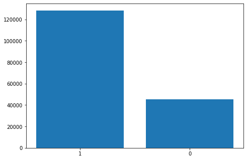

```python
Approval_count = data1['Approval_indicator'].value_counts()
Approval_count = pd.DataFrame({'Indicator':Approval_count.index, 'count':Approval_count.values})
display(Approval_count.head(10).style.hide_index())
# plt.bar(Approval_count['Indicator'], Approval_count['count'])
# plt.show()
fig = plt.figure()
ax = fig.add_axes([0,0,1,1])
x = ['1', '0']
ax.bar(x,Approval_count['count'])
plt.show()
```

```python
# Split dataset into 50% training and 50% test
X_train, X_test, Y_train, Y_test = train_test_split(X, Y, test_size = 0.5, random_state = None)
X_train.head(10)
```

|  | bin | retry_indicator |
| --- | --- | --- |
| 152088 | 542432 | 0 |
| 26371 | 413177 | 0 |
| 160049 | 517805 | 0 |
| 123781 | 601100 | 0 |
| 29767 | 415457 | 0 |
| 172388 | 540736 | 0 |
| 59664 | 446542 | 0 |
| 40008 | 542432 | 0 |
| 35050 | 483324 | 0 |
| 92691 | 411770 | 0 |

The following cell displays a decision tree after pruning.

*Note: The full decision tree is too large to be performed by my PC. Therefore, I used Google Colab to generate the full tree, as shown in the file "Full_tree.png".*

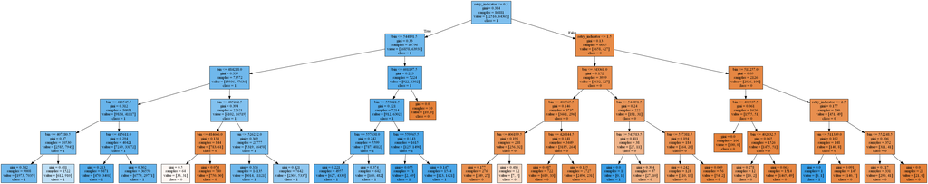

```python
# Decision tree with pruning.

clf = tree.DecisionTreeClassifier(max_depth = 5)
clf.fit(X_train, Y_train)

graph = Source(tree.export_graphviz(clf, out_file=None, feature_names=X.columns, class_names=['0', '1'], filled=True))
graph.format = 'png'
graph.render('Pruned',view = True)

# Display the tree
IPdisplay.Image('Pruned.png')
```

```python
# Predict the response for test dataset
Y_pred = clf.predict(X_test)
print("Accuracy:",round(metrics.accuracy_score(Y_test, Y_pred) * 100, 2), "%")
```

```
Accuracy: 80.69 %
```

```python
# fpr, tpr, _ = roc_curve(Y_test, Y_pred)
# roc_auc = auc(fpr, tpr)
```

```python
# plt.figure()
# lw = 2
# plt.plot(fpr, tpr, color='darkorange',
#          lw=lw, label='ROC curve (area = %0.2f)' % roc_auc)
# plt.plot([0, 1], [0, 1], color='navy', lw=lw, linestyle='--')
# plt.xlim([0.0, 1.0])
# plt.ylim([0.0, 1.05])
# plt.xlabel('False Positive Rate')
# plt.ylabel('True Positive Rate')
# plt.title('ROC Curve')
# plt.legend(loc="lower right")
# plt.show()
```

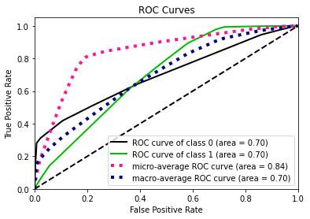

```python
import scikitplot.plotters as skplt
Y_pred_proba = clf.predict_proba(X_test)
skplt.plot_roc_curve(Y_test, Y_pred_proba)
```

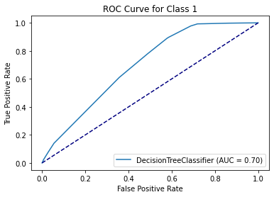

```python
from sklearn.metrics import plot_roc_curve
clf_disp = plot_roc_curve(clf, X_test, Y_test)
plt.plot([0, 1], [0, 1], color='navy', linestyle='--')
plt.title('ROC Curve for Class 1')
plt.show()
```

### Conclusion: A simple decision tree with 5 layers can achieve about 81% accuracy.

Next, lets try to find a better model without overfitting.

```
Optimal depth: 16
Accuracy: 83.66 %
```

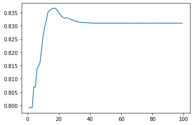

```python
optimal_depth = []
tree_accuracy = []
for depth in range(1, 100):
    optimal_depth.append(depth)
    clf = tree.DecisionTreeClassifier(max_depth = depth)
    clf.fit(X_train, Y_train)
    Y_pred = clf.predict(X_test)
    tree_accuracy.append(metrics.accuracy_score(Y_test, Y_pred))


print("Optimal depth:", optimal_depth[tree_accuracy.index(max(tree_accuracy))])
print("Accuracy:", round(max(tree_accuracy)*100, 2), "%")
plt.plot(optimal_depth, tree_accuracy)
plt.show()
```

###### Conclusion: depth = 16 decision tree gives us a more accurate prediction, with 83.66% accuracy.

Note: Other options like criterion="entropy" etc. may improve the accuracy as well.

For example, change the line to:

> clf = tree.DecisionTreeClassifier(**criterion="entropy"**, max_depth = depth)

Since the idea is similar, we won't repeat in here.

## Random Forest

```python
from sklearn.ensemble import RandomForestClassifier
clf_RF = RandomForestClassifier(n_estimators=1000)
clf_RF.fit(X_train,Y_train)
Y_pred=clf_RF.predict(X_test)
# print(metrics.accuracy_score(Y_test, Y_pred))
print("Accuracy:",round(metrics.accuracy_score(Y_test, Y_pred) * 100, 2), "%")
```

```
Accuracy: 83.64 %
```

```python
# Too slow on my computer

# optimal_depth = []
# tree_accuracy = []
# for depth in range(1, 1000):
#     optimal_depth.append(depth)
#     clf_RF = RandomForestClassifier(n_estimators=depth)
#     clf.fit(X_train, Y_train)
#     Y_pred = clf.predict(X_test)
#     tree_accuracy.append(metrics.accuracy_score(Y_test, Y_pred))


# print("Optimal depth:", optimal_depth[tree_accuracy.index(max(tree_accuracy))])
# print("Accuracy:", round(max(tree_accuracy)*100, 2), "%")
# plt.plot(optimal_depth, tree_accuracy)
# plt.show()
```

```python
# fpr, tpr, _ = roc_curve(Y_test, Y_pred)
# roc_auc = auc(fpr, tpr)
# roc_auc
```

```python
# plt.figure()
# lw = 2
# plt.plot(fpr, tpr, color='darkorange',
#          lw=lw, label='ROC curve (area = %0.2f)' % roc_auc)
# plt.plot([0, 1], [0, 1], color='navy', lw=lw, linestyle='--')
# plt.xlim([0.0, 1.0])
# plt.ylim([0.0, 1.05])
# plt.xlabel('False Positive Rate')
# plt.ylabel('True Positive Rate')
# plt.title('ROC Curve')
# plt.legend(loc="lower right")
# plt.show()
```

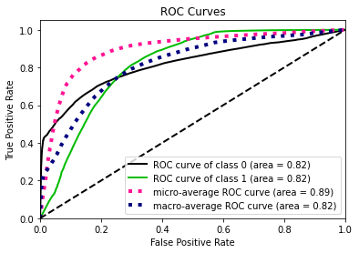

```python
import scikitplot.plotters as skplt
Y_pred_proba = clf_RF.predict_proba(X_test)
skplt.plot_roc_curve(Y_test, Y_pred_proba)
plt.show()
```

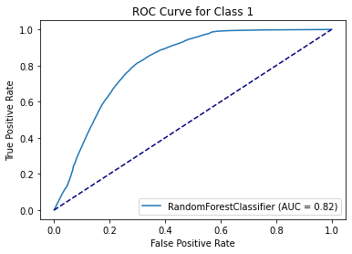

```python
from sklearn.metrics import plot_roc_curve
clf_disp = plot_roc_curve(clf_RF, X_test, Y_test)
plt.plot([0, 1], [0, 1], color='navy', linestyle='--')
plt.title('ROC Curve for Class 1')
plt.show()
```

```python
# test = data1.groupby(['order_id', 'bin']).size()
# [item[1] for item in test.index]

# if 517805 in [item[1] for item in test.index]:
#     print('True')
```

```python
# bin_count['count'].shape
# data1['bin'].shape
```

```python
##### Export to html #####
# import os

# os.system('jupyter nbconvert --to html Project.ipynb')
```

[output not shown]